# Mnohorozměrné statistické metody - Vína

Martin Žoha

2025-09-08

## Zadání

Pro zpracování úkolu použijte databázi o červených italských vínech.

1. Je významný rozdíl mezi jednotlivými odrůdami v jejich chemickém složení? Ve které charakteristice se odrůdy nejvíce odlišují?
2. Pokuste se data zjednodušit, tj. najít několik málo nových proměnných, které když použiji namísto těch stávajících, tak ztratím co nejméně informace. Kolik takových proměnných potřebuji? A je možné je nějak interpretovat? Najděte rozumný počet nových proměnných, které nějakou interpretaci mít budou. Jejich počet se může lišit od doporučeného čísla. Kolik procent informace tyto proměnné obsahují?
3. Je možné na základě chemické analýzy vzorku vína poznat, ke které odrůdě víno patří? Určete vhodnou funkci / funkce, které Vám neznámý vzorek pomohou přiřadit ke správné skupině. Jak je taková rozhodovací funkce dobrá? A kolik takovýchto funkcí potřebujete?
4. V tomto případě pracujte bez znalosti odrůdy a jen na základě číselných proměnných rozdělte data do skupin. Porovnejte více variant dělení do skupin (různé metody, různé počty skupin, …) a jedno dělení vyberte jako optimální. Kolik skupin máte? A jak byste tyto skupiny charakterizovali?

## Zpracování

### Načtení dat a počáteční průzkum

```r
wineUrl <- 'http://archive.ics.uci.edu/ml/machine-learning-databases/wine/wine.data'
wine <- read.table(wineUrl, header=FALSE, sep=',', stringsAsFactors=FALSE,
           col.names=c('Cultivar', 'Alcohol', 'Malic.acid','Ash', 'Alcalinity.of.ash',
                      'Magnesium', 'Total.phenols','Flavanoids', 'Nonflavanoid.phenols',
                      'Proanthocyanin', 'Color.intensity', 'Hue', 'OD280.OD315.of.diluted.wines',
                      'Proline'))
str(wine)
```

```
## 'data.frame':    178 obs. of  14 variables:
##  $ Cultivar                    : int  1 1 1 1 1 1 1 1 1 1 ...
##  $ Alcohol                     : num  14.2 13.2 13.2 14.4 13.2 ...
##  $ Malic.acid                  : num  1.71 1.78 2.36 1.95 2.59 1.76 1.87 2.15 1.64 1.35 ...
##  $ Ash                         : num  2.43 2.14 2.67 2.5 2.87 2.45 2.45 2.61 2.17 2.27 ...
##  $ Alcalinity.of.ash           : num  15.6 11.2 18.6 16.8 21 15.2 14.6 17.6 14 16 ...
##  $ Magnesium                   : int  127 100 101 113 118 112 96 121 97 98 ...
##  $ Total.phenols               : num  2.8 2.65 2.8 3.85 2.8 3.27 2.5 2.6 2.8 2.98 ...
##  $ Flavanoids                  : num  3.06 2.76 3.24 3.49 2.69 3.39 2.52 2.51 2.98 3.15 ...
##  $ Nonflavanoid.phenols        : num  0.28 0.26 0.3 0.24 0.39 0.34 0.3 0.31 0.29 0.22 ...
##  $ Proanthocyanin              : num  2.29 1.28 2.81 2.18 1.82 1.97 1.98 1.25 1.98 1.85 ...
##  $ Color.intensity             : num  5.64 4.38 5.68 7.8 4.32 6.75 5.25 5.05 5.2 7.22 ...
##  $ Hue                         : num  1.04 1.05 1.03 0.86 1.04 1.05 1.02 1.06 1.08 1.01 ...
##  $ OD280.OD315.of.diluted.wines: num  3.92 3.4 3.17 3.45 2.93 2.85 3.58 3.58 2.85 3.55 ...
##  $ Proline                     : int  1065 1050 1185 1480 735 1450 1290 1295 1045 1045 ...
```

```r
summary(wine)
```

```
##     Cultivar        Alcohol        Malic.acid         Ash
##  Min.   :1.000   Min.   :11.03   Min.   :0.740   Min.   :1.360
##  1st Qu.:1.000   1st Qu.:12.36   1st Qu.:1.603   1st Qu.:2.210
##  Median :2.000   Median :13.05   Median :1.865   Median :2.360
##  Mean   :1.938   Mean   :13.00   Mean   :2.336   Mean   :2.367
##  3rd Qu.:3.000   3rd Qu.:13.68   3rd Qu.:3.083   3rd Qu.:2.558
##  Max.   :3.000   Max.   :14.83   Max.   :5.800   Max.   :3.230
##  Alcalinity.of.ash   Magnesium      Total.phenols     Flavanoids
##  Min.   :10.60     Min.   : 70.00   Min.   :0.980   Min.   :0.340
##  1st Qu.:17.20     1st Qu.: 88.00   1st Qu.:1.742   1st Qu.:1.205
##  Median :19.50     Median : 98.00   Median :2.355   Median :2.135
##  Mean   :19.49     Mean   : 99.74   Mean   :2.295   Mean   :2.029
##  3rd Qu.:21.50     3rd Qu.:107.00   3rd Qu.:2.800   3rd Qu.:2.875
##  Max.   :30.00     Max.   :162.00   Max.   :3.880   Max.   :5.080
##  Nonflavanoid.phenols Proanthocyanin  Color.intensity       Hue
##  Min.   :0.1300       Min.   :0.410   Min.   : 1.280   Min.   :0.4800
##  1st Qu.:0.2700       1st Qu.:1.250   1st Qu.: 3.220   1st Qu.:0.7825
##  Median :0.3400       Median :1.555   Median : 4.690   Median :0.9650
##  Mean   :0.3619       Mean   :1.591   Mean   : 5.058   Mean   :0.9574
##  3rd Qu.:0.4375       3rd Qu.:1.950   3rd Qu.: 6.200   3rd Qu.:1.1200
##  Max.   :0.6600       Max.   :3.580   Max.   :13.000   Max.   :1.7100
##  OD280.OD315.of.diluted.wines    Proline
##  Min.   :1.270                Min.   : 278.0
##  1st Qu.:1.938                1st Qu.: 500.5
##  Median :2.780                Median : 673.5
##  Mean   :2.612                Mean   : 746.9
##  3rd Qu.:3.170                3rd Qu.: 985.0
##  Max.   :4.000                Max.   :1680.0
```

Popis datové sady ukazuje standardní tabulková data o 178 pozorováních a 14 sloupcích. Cultivar je momentálně celočíselná hodnota 1–3, kterou je nutné převést na faktor. Ostatní proměnné jsou numerické dle očekávání. Chybějící hodnoty se v souhrnu neobjevují. Rozsahy a mediány indikují značnou variabilitu mezi proměnnými: Alcohol kolem 11–15 s průměrem ~13, Malic.acid značně rozptýlený (0.74–5.80, mean ~2.34), Proline a Color.intensity mají nejširší škály (Proline 278–1680, Color.intensity 1.28–13) a Magnesium také větší rozsah, takže bez škálování budou tyto proměnné dominovat vzdálenostním a PCA metodám. Flavonoidy a Total.phenols vykazují rozdílné rozdělení a mohou být silně diskriminační, zatímco Hue či Nonflavanoid.phenols mají menší rozptyl; to naznačuje smysl pro multivariační testy, PCA a diskriminační analýzu po přepočtu Cultivar na faktor a standardizaci číselných proměnných.

```r
wine$Cultivar <- factor(wine$Cultivar)
X <- wine[, -1]
```

### 1. Rozdíly mezi odrůdami (MANOVA + jednorozměrné ANOVA)

#### Testované hypotézy

##### Multivariační test (MANOVA)

- H0: Vektor středních hodnot všech sledovaných proměnných je stejný ve všech skupinách (odrůdách vína).
- H1: Alespoň pro jednu proměnnou se střední hodnoty mezi odrůdami liší.

##### Jednorozměrné ANOVY (pro každou proměnnou zvlášť)

Pro každou z 13 proměnných (např. Flavanoids, Proline, Alcohol, …):

- H0: Průměrná hodnota dané proměnné je stejná u všech tří odrůd vína.
- H1: Existuje alespoň jedna odrůda, která se v průměrné hodnotě této proměnné liší od ostatních.

```r
fit <- manova(as.matrix(X) ~ Cultivar, data = wine)
# multivariatni test (Wilks)
manova_summary <- summary(fit, test = "Wilks")
manova_summary
```

```
##            Df    Wilks approx F num Df den Df    Pr(>F)
## Cultivar    2 0.019341    77.62     26    326 < 2.2e-16 ***
## Residuals 175
## ---
## Signif. codes:  0 '***' 0.001 '**' 0.01 '*' 0.05 '.' 0.1 ' ' 1
```

```r
# jednorozmerne ANOVY -> ktere promenne nejvice rozlisují
anova_list <- summary.aov(fit)
anova_list
```

```
##  Response Alcohol :
##              Df Sum Sq Mean Sq F value    Pr(>F)
## Cultivar      2 70.795  35.397  135.08 < 2.2e-16 ***
## Residuals   175 45.859   0.262
## ---
## Signif. codes:  0 '***' 0.001 '**' 0.01 '*' 0.05 '.' 0.1 ' ' 1
##
##  Response Malic.acid :
##              Df  Sum Sq Mean Sq F value    Pr(>F)
## Cultivar      2  65.578  32.789  36.943 4.127e-14 ***
## Residuals   175 155.321   0.888
## ---
## Signif. codes:  0 '***' 0.001 '**' 0.01 '*' 0.05 '.' 0.1 ' ' 1
##
##  Response Ash :
##              Df  Sum Sq Mean Sq F value   Pr(>F)
## Cultivar      2  1.7592 0.87961  13.313 4.15e-06 ***
## Residuals   175 11.5626 0.06607
## ---
## Signif. codes:  0 '***' 0.001 '**' 0.01 '*' 0.05 '.' 0.1 ' ' 1
##
##  Response Alcalinity.of.ash :
##              Df  Sum Sq Mean Sq F value    Pr(>F)
## Cultivar      2  572.83 286.417  35.772 9.444e-14 ***
## Residuals   175 1401.19   8.007
## ---
## Signif. codes:  0 '***' 0.001 '**' 0.01 '*' 0.05 '.' 0.1 ' ' 1
##
##  Response Magnesium :
##              Df Sum Sq Mean Sq F value    Pr(>F)
## Cultivar      2   4491 2245.50   12.43 8.963e-06 ***
## Residuals   175  31615  180.66
## ---
## Signif. codes:  0 '***' 0.001 '**' 0.01 '*' 0.05 '.' 0.1 ' ' 1
##
##  Response Total.phenols :
##              Df Sum Sq Mean Sq F value    Pr(>F)
## Cultivar      2 35.857 17.9284  93.733 < 2.2e-16 ***
## Residuals   175 33.472  0.1913
## ---
```

[output cut: 35 more lines]

```
## Signif. codes:  0 '***' 0.001 '**' 0.01 '*' 0.05 '.' 0.1 ' ' 1
##
##  Response OD280.OD315.of.diluted.wines :
##              Df Sum Sq Mean Sq F value    Pr(>F)
## Cultivar      2 61.087 30.5435  189.97 < 2.2e-16 ***
## Residuals   175 28.136  0.1608
## ---
## Signif. codes:  0 '***' 0.001 '**' 0.01 '*' 0.05 '.' 0.1 ' ' 1
##
##  Response Proline :
##              Df   Sum Sq Mean Sq F value    Pr(>F)
## Cultivar      2 12353665 6176832  207.92 < 2.2e-16 ***
## Residuals   175  5198844   29708
## ---
## Signif. codes:  0 '***' 0.001 '**' 0.01 '*' 0.05 '.' 0.1 ' ' 1
```

```r
# vypocet "eta^2" (podil mezi-group SS na total SS) pro kazdou promenou
eta2 <- sapply(names(anova_list), function(nm){
a <- anova_list[[nm]]
SSA <- a[1, "Sum Sq"]
SST <- sum(a[, "Sum Sq"])
SSA / SST
})
eta2_df <- data.frame(Variable = names(eta2), Eta2 = eta2)
eta2_df[order(-eta2_df$Eta2), ]
```

```
##                                                                      Variable
##  Response Flavanoids                                      Response Flavanoids
##  Response Proline                                            Response Proline
##  Response OD280.OD315.of.diluted.wines  Response OD280.OD315.of.diluted.wines
##  Response Alcohol                                            Response Alcohol
##  Response Color.intensity                            Response Color.intensity
##  Response Hue                                                    Response Hue
##  Response Total.phenols                                Response Total.phenols
##  Response Malic.acid                                      Response Malic.acid
##  Response Alcalinity.of.ash                        Response Alcalinity.of.ash
##  Response Proanthocyanin                              Response Proanthocyanin
##  Response Nonflavanoid.phenols                  Response Nonflavanoid.phenols
##  Response Ash                                                    Response Ash
##  Response Magnesium                                        Response Magnesium
##                                             Eta2
##  Response Flavanoids                   0.7277755
##  Response Proline                      0.7038119
##  Response OD280.OD315.of.diluted.wines 0.6846532
##  Response Alcohol                      0.6068787
##  Response Color.intensity              0.5796584
##  Response Hue                          0.5365878
##  Response Total.phenols                0.5171961
##  Response Malic.acid                   0.2968692
##  Response Alcalinity.of.ash            0.2901855
##  Response Proanthocyanin               0.2570351
##  Response Nonflavanoid.phenols         0.2396291
##  Response Ash                          0.1320555
##  Response Magnesium                    0.1243834
```

Multivariační test Wilksovým λ ukazuje extrémně silný celkový efekt kultivaru na všech 13 proměnných (λ = 0,019, F(26,326) = 77,6, p < 2,2e−16, p-hodnota < 0,05 znamená, že zamítáme H0), což potvrzuje, že mnohorozměrně se skupiny výrazně liší. Jednotlivé ANOVY s výpočtem eta² naznačují, které znaky nesou největší diskriminační informaci: nejvýrazněji rozlišují Flavanoids (η² ≈ 0,73), Proline (0,70) a OD280/OD315 (0,68), tedy ukazatele obsahu fenolických látek a spektrálních vlastností vín, spolu s Alcohol (0,61) a Color.intensity (0,58). Naopak Ash a Magnesium mají jen slabou vysvětlovanou variabilitu (< 0,15), tudíž se mezi kultivary překrývají. Celkově je rozlišení mezi třemi odrůdami silně podmíněno fenolickým profilem a intenzitou barvy, zatímco elementární složky hrají menší roli. U všech 13 proměnných je p-hodnota nízká (většinou < 2,2e-16, největší ≈ 9e-6). To znamená, že nulové hypotézy u všech proměnných zamítáme. Všechny sledované znaky se statisticky významně liší mezi odrůdami vín.

Multivariační test jednoznačně potvrzuje statisticky významné rozdíly v chemickém složení mezi třemi odrůdami vín. Největší rozdíly se ukazují v obsahu flavonoidů, který má nejvyšší podíl vysvětlené variability (η² ≈ 0,73), těsně následovaný koncentrací prolinu a poměrem OD280/OD315, tedy ukazateli fenolického profilu a spektrálních vlastností vín.

### 2. Redukce dimenzionality — PCA (prcomp)

```r
pc <- prcomp(X, scale. = TRUE)
# Variabilita
var_prop <- (pc$sdev^2) / sum(pc$sdev^2)
cumvar <- cumsum(var_prop)
round(rbind(var_prop = var_prop[1:6], cumvar = cumvar[1:6]), 3)
```

```
##           [,1]  [,2]  [,3]  [,4]  [,5]  [,6]
## var_prop 0.362 0.192 0.111 0.071 0.066 0.049
## cumvar   0.362 0.554 0.665 0.736 0.802 0.851
```

```r
# kolik PC pro >= 90%?
needed_90 <- which(cumvar >= 0.90)[1]
needed_90
```

```
## [1] 8
```

```r
# interpretace prvnich 3 PC
loadings <- pc$rotation
top_loadings(loadings, 1, 6)
```

```
##                                                  Variable    Loading
## Flavanoids                                     Flavanoids -0.4229343
## Total.phenols                               Total.phenols -0.3946608
## OD280.OD315.of.diluted.wines OD280.OD315.of.diluted.wines -0.3761674
## Proanthocyanin                             Proanthocyanin -0.3134295
## Nonflavanoid.phenols                 Nonflavanoid.phenols  0.2985331
## Hue                                                   Hue -0.2967146
```

```r
top_loadings(loadings, 2, 6)
```

```
##                        Variable    Loading
## Color.intensity Color.intensity -0.5299957
## Alcohol                 Alcohol -0.4836515
## Proline                 Proline -0.3649028
## Ash                         Ash -0.3160688
## Magnesium             Magnesium -0.2996340
## Hue                         Hue  0.2792351
```

```r
top_loadings(loadings, 3, 6)
```

```
##                                                  Variable    Loading
## Ash                                                   Ash  0.6262239
## Alcalinity.of.ash                       Alcalinity.of.ash  0.6120803
## Alcohol                                           Alcohol -0.2073826
## Nonflavanoid.phenols                 Nonflavanoid.phenols  0.1703682
## OD280.OD315.of.diluted.wines OD280.OD315.of.diluted.wines  0.1660046
## Flavanoids                                     Flavanoids  0.1506819
```

```r
# Faktorová analýza se 3 faktory (dle výsledků PCA)
fa <- factanal(X, factors = 3, rotation = "varimax") # varimax je default
fa
```

```
##
## Call:
## factanal(x = X, factors = 3, rotation = "varimax")
##
## Uniquenesses:
##                      Alcohol                   Malic.acid
##                        0.387                        0.727
##                          Ash            Alcalinity.of.ash
##                        0.522                        0.073
##                    Magnesium                Total.phenols
##                        0.837                        0.199
##                   Flavanoids         Nonflavanoid.phenols
##                        0.069                        0.658
##               Proanthocyanin              Color.intensity
##                        0.555                        0.246
##                          Hue OD280.OD315.of.diluted.wines
##                        0.503                        0.252
##                      Proline
##                        0.384
##
## Loadings:
##                              Factor1 Factor2 Factor3
## Alcohol                               0.779
## Malic.acid                   -0.470           0.213
## Ash                                   0.285   0.629
## Alcalinity.of.ash            -0.300  -0.322   0.856
## Magnesium                     0.126   0.373
## Total.phenols                 0.824   0.347
## Flavanoids                    0.928   0.265
## Nonflavanoid.phenols         -0.533  -0.144   0.193
## Proanthocyanin                0.622   0.230
## Color.intensity              -0.413   0.748   0.157
## Hue                           0.654  -0.202  -0.172
## OD280.OD315.of.diluted.wines  0.864
## Proline                       0.355   0.688  -0.129
##
##                Factor1 Factor2 Factor3
## SS loadings      4.009   2.277   1.302
## Proportion Var   0.308   0.175   0.100
## Cumulative Var   0.308   0.484   0.584
##
## Test of the hypothesis that 3 factors are sufficient.
## The chi square statistic is 158.55 on 42 degrees of freedom.
## The p-value is 1.96e-15
```

```r
# Faktorová zatížení (loadings)
print(fa$loadings, cutoff = 0.3)
```

```
##
## Loadings:
##                              Factor1 Factor2 Factor3
## Alcohol                               0.779
## Malic.acid                   -0.470
## Ash                                           0.629
## Alcalinity.of.ash                    -0.322   0.856
## Magnesium                             0.373
## Total.phenols                 0.824   0.347
## Flavanoids                    0.928
## Nonflavanoid.phenols         -0.533
## Proanthocyanin                0.622
## Color.intensity              -0.413   0.748
## Hue                           0.654
## OD280.OD315.of.diluted.wines  0.864
## Proline                       0.355   0.688
##
##                Factor1 Factor2 Factor3
## SS loadings      4.009   2.277   1.302
## Proportion Var   0.308   0.175   0.100
## Cumulative Var   0.308   0.484   0.584
```

```r
# Výpočet faktorových skóre pro jednotlivá pozorování
sc <- factanal(~Alcohol + Malic.acid + Ash + Alcalinity.of.ash +
                 Magnesium + Total.phenols + Flavanoids +
                 Nonflavanoid.phenols + Proanthocyanin +
                 Color.intensity + Hue + OD280.OD315.of.diluted.wines +
                 Proline,
               factors = 3, data = wine, scores = "Bartlett")$scores

# Faktorové skóre
head(sc)
```

```
##     Factor1   Factor2    Factor3
## 1 0.9891313 1.1361103 -0.5680500
## 2 0.6898495 0.4489189 -2.4160664
## 3 1.0335828 0.8932429  0.4570695
## 4 1.1587296 2.3233499  0.2931313
## 5 0.6810946 0.2449106  1.0036318
## 6 0.8943921 1.9359755 -0.4741061
```

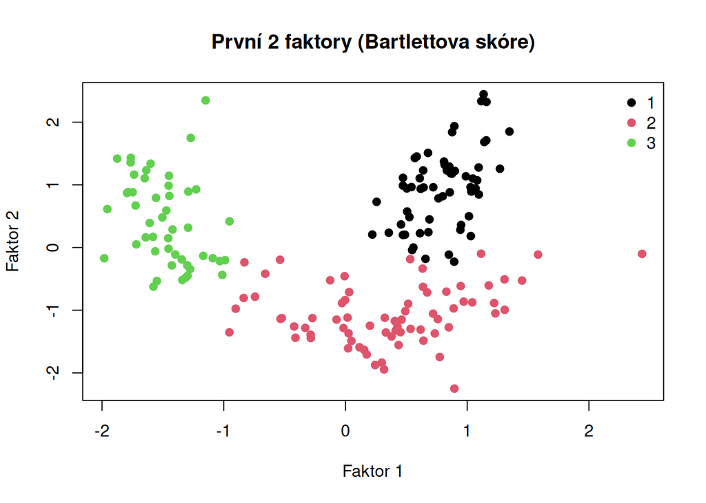

```r
# Grafické zobrazení – první dva faktory
plot(sc[,1], sc[,2], pch = 19,
     col = wine$Cultivar,
     main = "První 2 faktory (Bartlettova skóre)",
     xlab = "Faktor 1", ylab = "Faktor 2")
legend("topright", legend = levels(wine$Cultivar),
       col = 1:3, pch = 19, bty = "n")
```

#### PCA

Analýza hlavních komponent ukazuje, že první tři komponenty vysvětlují zhruba 67 % variability (36 %, 19 % a 11 %), a k dosažení hranice 90 % je třeba osmi komponent, které nahradí původních třináct a ztráta informace bude malá. To znamená, že datová struktura je poměrně komplexní. První komponenta je nejsilněji svázána s fenolickými látkami (flavonoidy, celkové fenoly, OD280/OD315) a charakterizuje tedy fenolický profil vín. Druhá komponenta odráží především obsah alkoholu, intenzitu barvy a prolin, tedy ukazatele alkoholové síly, zbarvení a zralosti hroznů. Třetí komponenta je nejvíce spojena s popelem a alkalinitou popela, tedy minerálním složením. Celkově lze říci, že největší rozlišovací schopnost mezi víny je v chemických ukazatelích fenolů a barvy, zatímco minerální složky se projeví až na dalších dimenzích.

| Komponenta | Vysvětlená variabilita | Hlavní proměnné (největší zátěže) | Interpretace |
| --- | --- | --- | --- |
| PC1 | 36 % | Flavanoids, Total.phenols, OD280/OD315, Proanthocyanin | Fenolický profil – látky ovlivňující chuť a stahující efekt |
| PC2 | 19 % | Color.intensity, Alcohol, Proline, Ash, Magnesium | Síla a barva vína – alkohol, intenzita barvy, zralost hroznů |
| PC3 | 11 % | Ash, Alcalinity.of.ash, Alcohol (opačná zátěž) | Mineralita – obsah popela a alkalita |

#### Faktorová analýza

Extrahovány jsou 3 faktory (výchozí varimax rotace), které vysvětlují dohromady 58 % variability. Test hypotézy o dostatečnosti 3 faktorů (χ² = 158,55, df = 42, p < 0.001) ukazuje, že nulová hypotéza, že 3 faktory postačují, je zamítnuta a pro přesnější popis by bylo třeba více faktorů. To také koresponduje s výsledky PCA (≥8 komponent pro 90 % variability).

Interpretace faktorů:

| Faktor | Součásti |
| --- | --- |
| **F1 (fenolický faktor):** | Flavanoids, Total phenols, OD280/OD315, Proanthocyanin, Hue. |
| **F2 (síla a barva vína):** | Alcohol, Color intensity, Proline. |
| **F3 (minerální faktor):** | Ash, Alcalinity of ash. |

### 3. Klasifikace (LDA, QDA) — lze podle chemie identifikovat odrůdu?

```r
# Train-test split 70:30
train_idx <- sample(nrow(wine), 0.7 * nrow(wine))
train_data <- wine[train_idx, ]
test_data <- wine[-train_idx, ]

# LDA s train-test
lda_fit <- lda(Cultivar ~ ., data = train_data)
lda_pred <- predict(lda_fit, test_data)
res_lda_split <- acc_table(test_data$Cultivar, lda_pred$class)
res_lda_split$table
```

```
##      Pred
## Truth  1  2  3
##     1 21  0  0
##     2  0 19  0
##     3  0  0 14
```

```r
res_lda_split$accuracy
```

```
## [1] 1
```

```r
# QDA s train-test
qda_fit <- qda(Cultivar ~ ., data = train_data)
qda_pred <- predict(qda_fit, test_data)
res_qda_split <- acc_table(test_data$Cultivar, qda_pred$class)
res_qda_split$table
```

```
##      Pred
## Truth  1  2  3
##     1 20  1  0
##     2  0 19  0
##     3  0  1 13
```

```r
res_qda_split$accuracy
```

```
## [1] 0.962963
```

```r
# LDA s LOOCV
lda_cv <- lda(Cultivar ~ ., data = wine, prior = c(1/3, 1/3, 1/3), CV = TRUE)
res_lda <- acc_table(wine$Cultivar, lda_cv$class)
res_lda$table
```

```
##      Pred
## Truth  1  2  3
##     1 59  0  0
##     2  1 69  1
##     3  0  0 48
```

```r
res_lda$accuracy
```

```
## [1] 0.988764
```

```r
# LDA bez CV (pro zobrazeni diskr. funkci)
lda_fit <- lda(Cultivar ~ ., data = wine)
# diskriminacni skore (2 funkce, protoze g=3)
head(predict(lda_fit)$x)
```

```
##         LD1       LD2
## 1 -4.700244 1.9791383
## 2 -4.301958 1.1704129
## 3 -3.420720 1.4291014
## 4 -4.205754 4.0028715
## 5 -1.509982 0.4512239
## 6 -4.518689 3.2131376
```

```r
# QDA s LOOCV
qda_cv <- qda(Cultivar ~ ., data = wine, prior = c(1/3, 1/3, 1/3), CV = TRUE)
res_qda <- acc_table(wine$Cultivar, qda_cv$class)
res_qda$table
```

```
##      Pred
## Truth  1  2  3
##     1 59  0  0
##     2  1 70  0
##     3  0  0 48
```

```r
res_qda$accuracy
```

```
## [1] 0.994382
```

Výsledky potvrzují, že chemické složení umožňuje vysoce přesnou identifikaci odrůd vín. LDA dosahuje přesnosti 100% na testovací sadě (train-test split) a 98,9% při LOOCV se stejnými apriorními pravděpodobnostmi. QDA vykazuje 96,3% přesnost na testovací sadě a 99,4% při LOOCV.

Rozdíl mezi metodami je minimální - QDA s LOOCV dosahuje nejlepších výsledků (99,4%), zatímco na samostatné testovací sadě překvapivě dominuje LDA (100% vs 96,3%). Chyby se vyskytují sporadicky, hlavně u odrůdy 2, kde dochází k záměně za odrůdy 1 nebo 3.

Pro tři odrůdy jsou potřebné dvě diskriminační funkce (LD1, LD2), které jednoznačně oddělují vzorky. Výsledky jednoznačně dokazují, že chemický profil je vysoce spolehlivým identifikátorem odrůd vín.

> lda {MASS} R Documentation  
> CV If true, returns results (classes and posterior probabilities) for leave-one-out cross-validation. Note that if the prior is estimated, the proportions in the whole dataset are used.

### 4. Shlukování bez znalosti odrůdy (hierarchické + k-means)

```r
Xs <- scale(X)
# hierarchicke (Ward)
d <- dist(Xs)
hc <- hclust(d, method = "ward.D2")
# zvolime 3 shluky, porovname s odrudami
cl_hc3 <- cutree(hc, k = 3)
table(Cluster = cl_hc3, Cultivar = wine$Cultivar)
```

```
##        Cultivar
## Cluster  1  2  3
##       1 59  5  0
##       2  0 58  0
##       3  0  8 48
```

```r
# kmeans: porovname k = 2..6 pomoci tot.withinss (elbow)
wss <- sapply(2:6, function(k) kmeans(Xs, centers = k, nstart = 25)$tot.withinss)
wss_df <- data.frame(k = 2:6, tot_withinss = wss)
wss_df
```

```
##   k tot_withinss
## 1 2     1649.440
## 2 3     1270.749
## 3 4     1168.614
## 4 5     1095.153
## 5 6     1035.810
```

```r
# zvolime k = 3 (typicky u tohoto datasetu)
km3 <- kmeans(Xs, centers = 3, nstart = 50)
table(KMeans = km3$cluster, Cultivar = wine$Cultivar)
```

```
##       Cultivar
## KMeans  1  2  3
##      1 59  3  0
##      2  0  3 48
##      3  0 65  0
```

```r
# charakteristika shluku (prumer puvodnich promennych)
aggregate(X, by = list(cluster = km3$cluster), mean)
```

```
##   cluster  Alcohol Malic.acid      Ash Alcalinity.of.ash Magnesium
## 1       1 13.67677   1.997903 2.466290          17.46290 107.96774
## 2       2 13.13412   3.307255 2.417647          21.24118  98.66667
## 3       3 12.25092   1.897385 2.231231          20.06308  92.73846
##   Total.phenols Flavanoids Nonflavanoid.phenols Proanthocyanin Color.intensity
## 1      2.847581  3.0032258            0.2920968       1.922097        5.453548
## 2      1.683922  0.8188235            0.4519608       1.145882        7.234706
## 3      2.247692  2.0500000            0.3576923       1.624154        2.973077
##         Hue OD280.OD315.of.diluted.wines   Proline
## 1 1.0654839                     3.163387 1100.2258
## 2 0.6919608                     1.696667  619.0588
## 3 1.0627077                     2.803385  510.1692
```

## Shrnutí

- **MANOVA**: Wilksův test ukazuje velmi významný rozdíl mezi odrůdami, což potvrzuje, že se chemické složení odrůd multivariačně liší.
- **Nejvíce rozlišující proměnné**: Flavanoids, Proline, OD280/OD315, Alcohol, Color.intensity, Hue – podle hodnot Eta² nejvíce přispívají k odlišení odrůd.
- **PCA**: První 2–3 komponenty vysvětlují cca 67 % variability; pro ≥90 % je potřeba 8 komponent. První komponenta odráží fenolický profil, druhá alkohol, barvu a prolin, třetí minerální složení.
- **Klasifikace**: LDA a QDA s LOOCV dosahují velmi vysoké přesnosti (LDA ~98,9 %, QDA ~99,4 %). Pro tři odrůdy jsou potřeba dvě diskriminační funkce.
- **Shlukování**: Optimální dělení do 3 skupin odpovídá přibližně skutečným odrůdám; hlavní charakteristiky clusterů jsou fenolický profil, alkohol, barva, prolin a minerální složení.